**Title:** “Methods and Analysis 1” **Author:** “Joe Littell” **Due date:** “September 6, 2018” **Output:** pdf_document

# **Question #1 - Old Faithful**

### This probrem deals with the wait for eruptions given how long the duration of the last eruption was.

```
##
## Call:
## lm(formula = Interval ~ Duration, data = oldf)
##
## Residuals:
##     Min      1Q  Median      3Q     Max
## -14.644  -4.440  -1.088   4.467  15.652
##
## Coefficients:
##             Estimate Std. Error t value Pr(>|t|)
## (Intercept)  33.8282     2.2618   14.96   <2e-16 ***
## Duration     10.7410     0.6263   17.15   <2e-16 ***
## ---
## Signif. codes:  0 '***' 0.001 '**' 0.01 '*' 0.05 '.' 0.1 ' ' 1
##
## Residual standard error: 6.683 on 105 degrees of freedom
## Multiple R-squared:  0.7369, Adjusted R-squared:  0.7344
## F-statistic: 294.1 on 1 and 105 DF,  p-value: < 2.2e-16
```

```
##                 2.5 %   97.5 %
## (Intercept) 29.343441 38.31297
## Duration     9.499061 11.98288
```

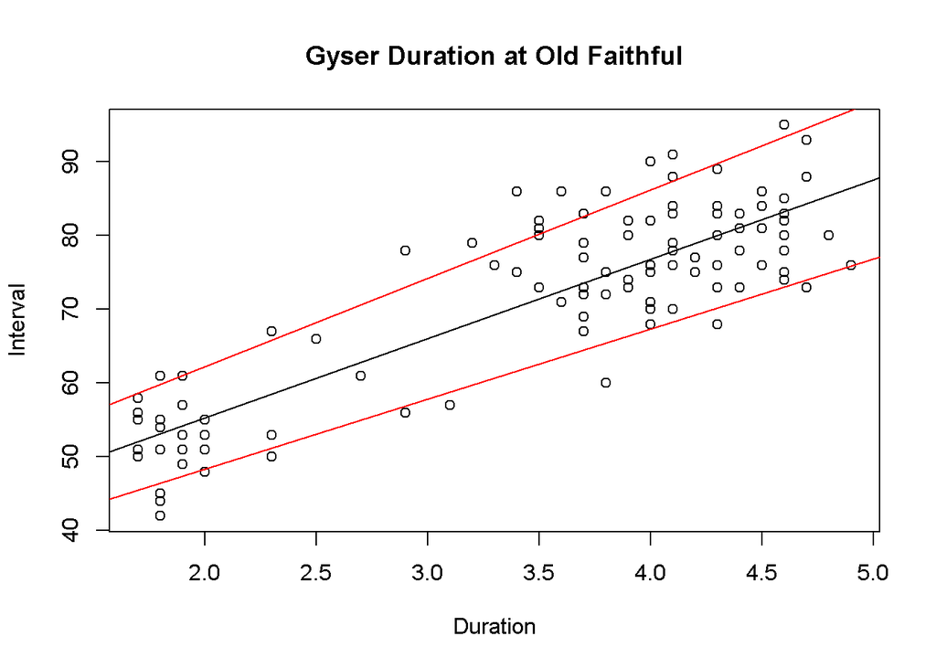

```
##        fit     lwr      upr
## 1 76.79209 63.4631 90.12108
```

From the initial plotting of the duration by the wait time, we can see a relatively straight forward postive correlation between duration and wait time. In that as the duration goes up, so does the wait time.

From the cosole data, we answer a few questions, namely the following;

**Intercept with Standard Error:**  
33.8282 2.2618 14.96 <2e-16 ***

**Slope with Standard Error:**  
10.7410 0.6263 17.15 <2e-16 ***

**R Squared:**  
Multiple R-squared: 0.7369, Adjusted R-squared: 0.7344

**95% confidence interval of the slope and intercept:**

*2.5 %*  
Intercept: 29.343441  
Slope: 9.499061  
*97.5 %*  
Intercept: 38.31297  
Slope: 11.98288

** Estimated wait interval **  
fit lwr upr  
1 76.79209 63.4631 90.12108

This model for grater than 4 minutes makes sense if we observe the graph. Wait intervals when the duration is between 3-5 minutes are clustered around 65-85, so an interval of 76 is well within the logical realm of possibility.

# **Question #2 - Respitory Rates**

### The second problem set deals with Respitory Rates for children under the age of 3 years old.

```
##
## Call:
## lm(formula = Rate ~ Age, data = resp)
##
## Residuals:
##     Min      1Q  Median      3Q     Max
## -19.652  -5.432  -0.608   4.589  32.270
##
## Coefficients:
##             Estimate Std. Error t value Pr(>|t|)
## (Intercept) 47.05216    0.50422   93.32   <2e-16 ***
## Age         -0.69571    0.02938  -23.68   <2e-16 ***
## ---
## Signif. codes:  0 '***' 0.001 '**' 0.01 '*' 0.05 '.' 0.1 ' ' 1
##
## Residual standard error: 7.842 on 616 degrees of freedom
## Multiple R-squared:  0.4766, Adjusted R-squared:  0.4758
## F-statistic: 560.9 on 1 and 616 DF,  p-value: < 2.2e-16
```

```
##                  2.5 %     97.5 %
## (Intercept) 46.0619711 48.0423556
## Age         -0.7534009 -0.6380259
```

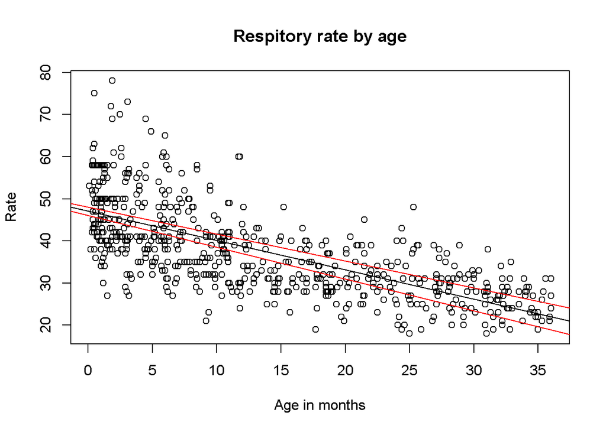

```
##        fit      lwr      upr
## 1 46.35645 30.92683 61.78607
```

```
##        fit      lwr      upr
## 1 34.52932 19.11397 49.94468
```

```
##        fit      lwr      upr
## 1 26.87648 11.43713 42.31582
```

**The model of the entire data set.**  
*2.5 %*  
Intercept: 46.0619711  
Slope: -0.7534009  
*97.5 %*  
Intercept: 48.0423556  
Slope: -0.6380259  
**The 95% perdiction model at 1 month of age**  
fit lwr upr  
1 46.35645 30.92683 61.78607

**The 95% perdiction model at 18 months of age**  
fit lwr upr  
1 34.52932 19.11397 49.94468

**The 95% perdiction model at 29 months of age**  
fit lwr upr  
1 26.87648 11.43713 42.31582

# **Question #3 - The 2000 Presidential Election**

### The last problem set deals with the 2000 Election and voter error in votes for Buchanan in Palm Beach County

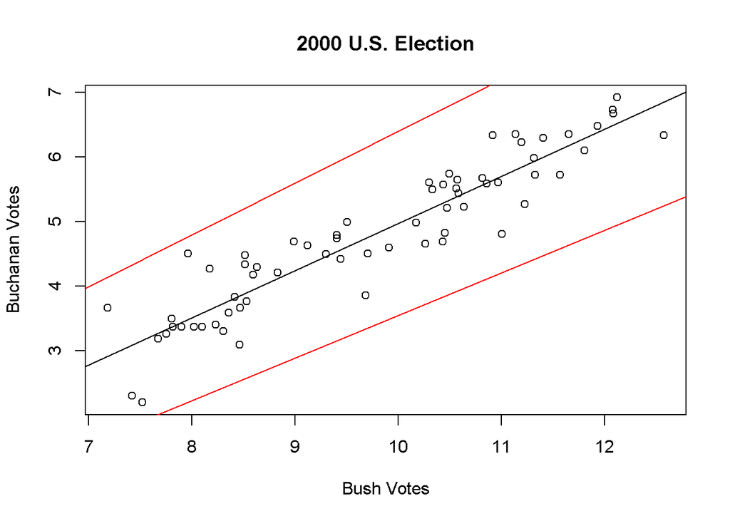

```
##
## Call:
## lm(formula = Buchanan2000 ~ Bush2000, data = elect)
##
## Residuals:
##      Min       1Q   Median       3Q      Max
## -0.95631 -0.21236  0.02503  0.28102  1.02056
##
## Coefficients:
##             Estimate Std. Error t value Pr(>|t|)
## (Intercept) -2.34149    0.35442  -6.607 9.07e-09 ***
## Bush2000     0.73096    0.03597  20.323  < 2e-16 ***
## ---
## Signif. codes:  0 '***' 0.001 '**' 0.01 '*' 0.05 '.' 0.1 ' ' 1
##
## Residual standard error: 0.4198 on 64 degrees of freedom
## Multiple R-squared:  0.8658, Adjusted R-squared:  0.8637
## F-statistic:   413 on 1 and 64 DF,  p-value: < 2.2e-16
```

```
##                 2.5 %    97.5 %
## (Intercept) -3.049512 -1.633461
## Bush2000     0.659109  0.802815
```

```
##        fit      lwr      upr
## 1 592.3769 250.8001 1399.164
```

```
## [1] 592.3606
```

After removing the Palm Beach data, it was still obvious that additional transformations were required. Both transforming Bush2000 and Buchanan2000 logrithmically was tested individually and together. The best results after looking at the residual plots was to use both.

**Prediction:**  
BuchananPB <- exp(0.73096*log(152846)-2.34149) which equals 592.3606

When we run the prediction model through R with only the Palm Beach County we see that;

```
   fit      lwr      upr
```

592.3769 250.8001 1399.164

This means we can assume that Buchanan potentially recieved approximately 2815 votes in error in the 2000 election based on the votes he recieved in other counties throughout Florida. (Votes recieved - Votes predicted or 3407- 592)